# Sac à dos et sélection de features

Projet M2 — Algorithmique

Mahir Dursunoglu

Juin 2026

# 1 Introduction

## 1.1 Le problème

On dispose de $n$ objets. Chaque objet $i$ a un poids entier $w_i > 0$ et une valeur $v_i > 0$. On veut choisir un sous-ensemble de valeur totale maximale sans dépasser un budget $W$ :

$$\max \sum_{i=1}^n v_i x_i \quad
\text{sujet à} \quad \sum_{i=1}^n w_i x_i \leq W, \quad x_i \in
\{0,1\}.$$

C’est le **problème du sac à dos 0-1**. Il est NP-difficile : on ne connaît pas d’algorithme exact polynomial en $n$ et $\log W$. Cependant, c’est un problème *faiblement* NP-difficile — la programmation dynamique le résout en $O(n \cdot W)$, ce qui est raisonnable si $W$ n’est pas trop grand. On parle de complexité pseudo-polynomiale.

## 1.2 Application : sélection de features

En apprentissage automatique, acquérir une feature peut coûter du temps de calcul, une mesure en laboratoire, etc. On peut alors modéliser la sélection de features comme un sac à dos :

- $w_i$ = coût d’acquisition de la feature $i$
- $v_i$ = gain de performance prédit (par exemple, l’information mutuelle avec la cible)
- $W$ = budget total disponible

Trouver le sous-ensemble optimal est exactement un problème de sac à dos. Pour $n = 30$ features, il y a $2^{30} \approx 10^9$ sous-ensembles possibles. L’énumération exhaustive n’est pas envisageable dès que $n$ dépasse 25 ou 30.

# 2 Méthodes

Le package `sacADos` propose trois méthodes. Les deux premières sont exactes ; la troisième est une heuristique en ligne de complexité $O(n)$, conçue pour traiter de grandes instances.

```r
inst <- generate_knapsack(n = 15, type = "uncorrelated")
```

| Méthode | Algorithme | Complexité | Exact | Impl. |
| --- | --- | --- | --- | --- |
| i | Énumération exhaustive | $O(2^n \cdot n)$ | Oui | R |
| ii | Programmation dynamique | $O(n \cdot W)$ | Oui | R + C++ |
| iii | Heuristique adaptative | $O(n)$ | Non | R + C++ |

## 2.1 Méthode i — Énumération exhaustive (R)

On représente chaque sous-ensemble par un masque binaire $k \in \{0, \ldots, 2^n - 1\}$. Le bit $j$ de $k$ vaut 1 si l’objet $j$ est pris. On parcourt tous les masques, on vérifie la contrainte de poids, et on retient la meilleure valeur.

Complexité : $O(2^n \cdot n)$. Utilisable jusqu’à $n \approx 25$.

```r
knapsack_naive(inst$W, inst$w, inst$v)$value
```

```
## [1] 8027
```

## 2.2 Méthode ii — Programmation dynamique (R et C++)

On construit la table de Bellman $M$ de taille $(n+1) \times (W+1)$, où $M[i][c]$ est la valeur optimale en se restreignant aux $i$ premiers objets avec une capacité $c$ :

$$M[i][c] = \begin{cases}
M[i-1][c] & \text{si } c < w_i, \\
\max\!\bigl(M[i-1][c],\; v_i + M[i-1][c - w_i]\bigr) & \text{sinon.}
\end{cases}$$

L’ensemble optimal est retrouvé par un retour arrière. Complexité $O(n \cdot W)$.

```r
knapsack_dp(inst$W, inst$w, inst$v)$value         # R
```

```
## [1] 8027
```

```r
knapsack_dp_Rcpp(inst$W, inst$w, inst$v)$value    # C++
```

```
## [1] 8027
```

## 2.3 Méthode iii — Heuristique adaptative en ligne (R et C++)

Les objets arrivent en flux, un par un. Pour chaque objet, on décide immédiatement de l’accepter ou non — sans revenir en arrière. L’idée centrale : plus le sac est rempli, plus on exige un bon rapport valeur/poids pour accepter un item.

Formellement, on accepte l’objet $i$ si et seulement si

$$\frac{v_i}{w_i} \geq \Psi(z), \qquad z =
\frac{\text{poids utilisé}}{W} \in [0,1],$$

où $\Psi : [0,1] \to \mathbb{R}^+$ est une fonction de seuil croissante. Notre contribution est une $\Psi$ **auto-calibrée** qui apprend les bornes de densité et la corrélation poids-valeur directement sur le flux. Complexité $O(n)$.

Le détail de la conception de $\Psi$ est l’objet de la question Q2.

```r
knapsack_adaptive(inst$w, inst$v, inst$W)$value   # R
```

```
## [1] 6692
```

# 3 Q1 — Génération d’instances

## 3.1 Pourquoi simuler ?

Pour mesurer la complexité empiriquement, il faut des instances de tailles variées et contrôlées. Les vrais jeux de données ont une taille fixe — impossible de faire varier $n$ librement. On utilise un générateur aléatoire paramétré.

## 3.2 Les quatre familles de Pisinger

Les distributions classiques pour le sac à dos sont définies par la relation entre $w_i$ et $v_i$. On tire les poids $w_i \sim \mathcal{U}\{1, R\}$ avec $R = 1000$, puis :

| Type | Valeurs $v_i$ | Corrélation $w$-$v$ |
| --- | --- | --- |
| `uncorrelated` | $\mathcal{U}\{1, R\}$, indépendant de $w$ | nulle |
| `weakly` | $w_i + \mathcal{U}\{-R/10, R/10\}$ | faible |
| `strongly` | $w_i + c$, $c = R/10$ fixe | forte |
| `subsetsum` | $v_i = w_i$ | parfaite |

Pour `strongly` et `subsetsum`, tous les items ont presque le même ratio $v_i/w_i$. Une heuristique basée sur ce ratio ne peut pas les distinguer — ce sont les cas difficiles (Q3).

## 3.3 Capacité

On fixe $W = \lfloor 0{,}5 \cdot \sum w_i \rfloor$. Un ratio de 0,5 est le plus difficile : la moitié des objets peut tenir dans le sac en poids, mais on ne sait pas lesquels choisir. Un ratio trop bas (presque rien ne rentre) ou trop élevé (presque tout rentre) rend le problème trivial.

## 3.4 Exemples

```r
types <- c("uncorrelated", "weakly", "strongly", "subsetsum")
insts <- lapply(types, function(t) generate_knapsack(n = 100, type = t))
names(insts) <- types
```

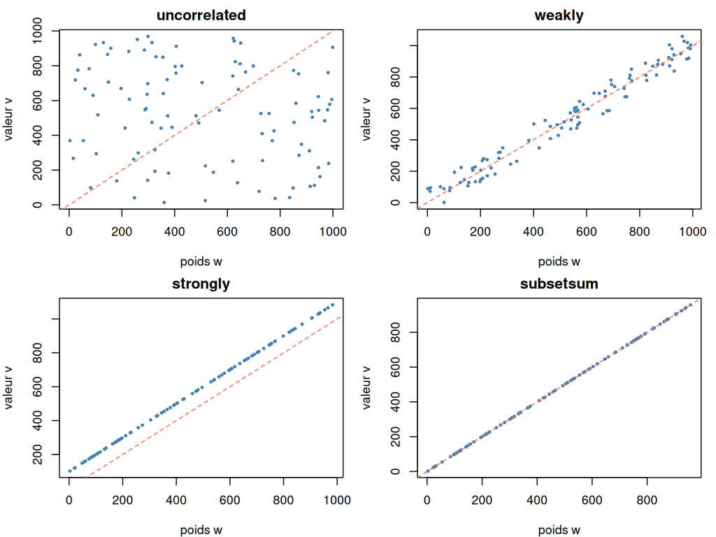

```r
par(mfrow = c(2, 2), mar = c(4, 4, 2, 1))
for (nm in types) {
  inst <- insts[[nm]]
  plot(inst$w, inst$v, pch = 16, cex = 0.6, col = "steelblue",
       xlab = "poids w", ylab = "valeur v", main = nm)
  abline(0, 1, col = "tomato", lty = 2)   # diagonale v = w
}
```

La ligne rouge est $v = w$. Pour `subsetsum`, tous les points sont exactement dessus. Pour `strongly`, ils sont décalés d’une constante $c$. Pour `uncorrelated`, aucune structure.

# 4 Q2 — L’heuristique proposée

## 4.1 Cadre en ligne

L’idée : les items arrivent un par un dans un ordre quelconque. Pour chaque item, on décide immédiatement de l’accepter ou non, sans revenir en arrière. C’est le **sac à dos en ligne** (*online knapsack*).

Ce cadre est naturel en sélection de features : les features peuvent arriver au fil du calcul, et on veut une décision instantanée sans attendre de tout voir.

## 4.2 La règle de décision

On accepte l’item $i$ si et seulement si il rentre dans le sac **et** son ratio dépasse un seuil :

$$\frac{v_i}{w_i} \geq \Psi(z), \qquad z =
\frac{\text{poids utilisé}}{W} \in [0,1].$$

$\Psi$ est croissante : plus le sac est plein, plus on est sélectif. Avec $L = \min_i v_i/w_i$ et $U = \max_i v_i/w_i$, trois formes classiques :

| Forme | $\Psi(z)$ | Remarque |
| --- | --- | --- |
| Linéaire | $L + (U-L)\,z$ | simple, aucune garantie |
| Puissance | $L + (U-L)\,z^p$ | un paramètre $p > 0$ |
| Exponentielle | $\frac{L}{e}\!\left(\frac{Ue}{L}\right)^{\!z}$ | optimale au pire cas, ratio $\ln(U/L)+1$ |

La forme exponentielle (Zhou, Chakrabarty & Lukose, 2008) minimise le ratio de compétitivité dans le pire cas. On l’utilise comme référence.

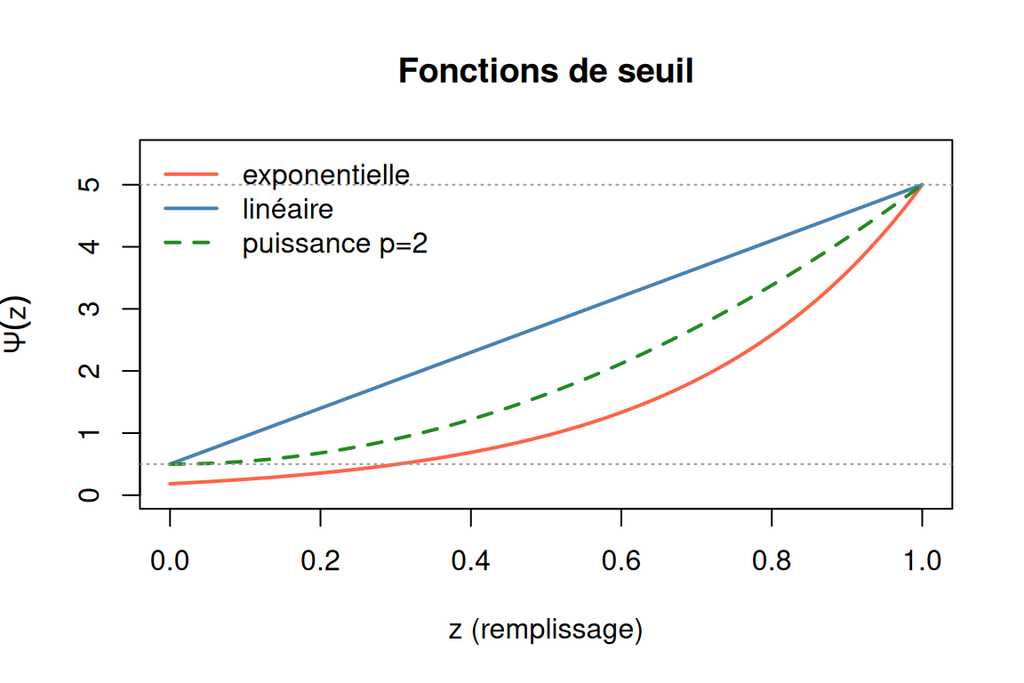

```r
z  <- seq(0, 1, length.out = 200)
L  <- 0.5; U <- 5
psi_lin <- L + (U - L) * z
psi_pow <- L + (U - L) * z^2
psi_exp <- (L / exp(1)) * (U * exp(1) / L)^z

plot(z, psi_exp, type = "l", col = "tomato", lwd = 2,
     ylim = c(0, U * 1.1), xlab = "z (remplissage)", ylab = expression(Psi(z)),
     main = "Fonctions de seuil")
lines(z, psi_lin, col = "steelblue", lwd = 2)
lines(z, psi_pow, col = "forestgreen", lwd = 2, lty = 2)
abline(h = c(L, U), lty = 3, col = "grey60")
legend("topleft", c("exponentielle", "linéaire", "puissance p=2"),
       col = c("tomato", "steelblue", "forestgreen"),
       lwd = 2, lty = c(1, 1, 2), bty = "n")
```

## 4.3 Notre Ψ auto-calibrée

Les formes ci-dessus supposent $L$ et $U$ connus à l’avance. En pratique on ne connaît pas la distribution des densités. Notre approche :

1. **Phase d’échauffement** : sur les 10 % premiers items, on estime $L$ et $U$ comme les quantiles 5 % et 95 % des densités observées, puis on gèle ces bornes.
2. **Corrélation apprise en ligne** : on maintient la corrélation de Pearson $\hat{\rho}$ entre $w$ et $v$ via six sommes cumulées (mise à jour en $O(1)$ par item).
3. **Sélectivité adaptée** : on calcule
   $$k = k_{\text{lo}} + (k_{\text{hi}} -
   k_{\text{lo}}) \cdot \max(0,\,\hat{\rho}).$$
   Si $\hat{\rho} \approx 1$ (strongly), le sac se remplit facilement — on peut être strict tôt ($k$ grand). Si $\hat{\rho} \approx 0$ (uncorrelated), on reste sélectif sur les hauts ratios ($k$ petit, défaut $k_{\text{lo}} = 4$, $k_{\text{hi}} = 30$).
4. **Décision** : on accepte si $v_i/w_i \geq p$ avec
   $$p = \text{clamp}\!\bigl(L + (U - L)(z + k(z -
   t)),\; L,\; U\bigr),$$
   où $t = (i-1)/n$ est la progression dans le flux. Le terme $k(z-t)$ est un correcteur de rythme : si le sac se remplit trop vite ($z > t$), le seuil monte ; sinon il baisse.
5. **Cas dégénéré** : si $(U-L)/U < 10^{-3}$ (type subsetsum, toutes les densités égales), on accepte simplement tout item qui rentre.

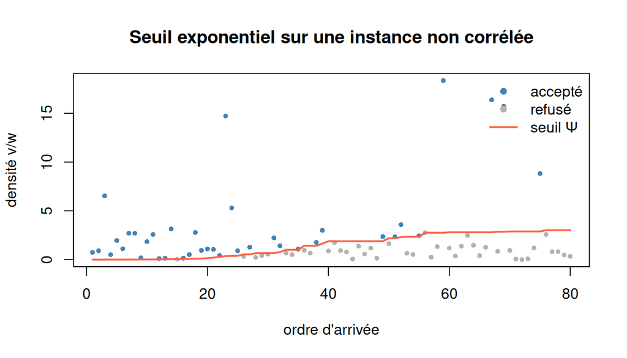

```r
set.seed(1)
inst2 <- generate_knapsack(n = 80, type = "uncorrelated")
tr <- knapsack_online(inst2$W, inst2$w, inst2$v,
                      psi_exponential(min(inst2$v / inst2$w),
                                      max(inst2$v / inst2$w)))$trace

plot(seq_len(nrow(tr)), tr$density, pch = 16, cex = 0.7,
     col = ifelse(tr$accepted, "steelblue", "grey70"),
     xlab = "ordre d'arrivée", ylab = "densité v/w",
     main = "Seuil exponentiel sur une instance non corrélée")
lines(seq_len(nrow(tr)), tr$threshold, col = "tomato", lwd = 2)
legend("topright", c("accepté", "refusé", "seuil Ψ"),
       col = c("steelblue", "grey70", "tomato"),
       pch = c(16, 16, NA), lty = c(NA, NA, 1), lwd = c(NA, NA, 2), bty = "n")
```

## 4.4 Borne LP et certification de la qualité

Pour mesurer la qualité de l’heuristique sans connaître OPT exactement, on utilise la **borne fractionnaire de Dantzig (1957)** : trier les items par $v_i/w_i$, remplir goulûment, puis fractionner le dernier item critique. Cette borne $U_{\text{LP}} \geq \text{OPT}$ se calcule en $O(n \log n)$.

Le gap heuristique est certifié par :
$$\text{gap} \leq \frac{U_{\text{LP}} -
H}{U_{\text{LP}}},$$
où $H$ est la valeur retournée. Si le gap est petit, l’heuristique est proche de l’optimum — sans avoir besoin de résoudre le problème exactement.

```r
H <- knapsack_adaptive(inst2$w, inst2$v, inst2$W)$value
U <- knapsack_lp_bound(inst2$W, inst2$w, inst2$v)
cat(sprintf("H = %d  |  borne LP = %.1f  |  gap <= %.1f%%\n",
            H, U, 100 * (U - H) / U))
```

```
## H = 30097  |  borne LP = 34427.2  |  gap <= 12.6%
```

# 5 Q3 — Instances difficiles pour l’heuristique

Deux types de difficulté, de nature différente.

## 5.1 Densités identiques (strongly, subsetsum)

Notre heuristique décide en comparant $v_i/w_i$ à un seuil $\Psi(z)$. Si tous les items ont la même densité — c’est exactement le cas `subsetsum` ($v_i = w_i$) et presque le cas `strongly` ($v_i = w_i + c$) — le seuil ne peut plus distinguer les items entre eux.

La décision se réduit à : *accepter tout ce qui rentre*. C’est un simple *first-fit*, sans aucune intelligence sur la valeur. Sur des instances de ce type, n’importe quel ordre d’arrivée donne un résultat différent, et rien ne garantit que les items choisis sont les meilleurs.

## 5.2 Ordre adversarial (croissant par densité)

Pour toute règle de seuil, il existe un ordre d’arrivée qui force le pire cas. Intuitivement :

- Les premiers items arrivent avec une densité juste sous le seuil → acceptés, ils remplissent le sac.
- Les derniers items sont très denses → refusés faute de place.

L’optimal aurait ignoré les premiers items et pris uniquement les derniers. On peut construire cet ordre explicitement en triant les items par densité croissante avant de les présenter à l’heuristique.

```r
set.seed(3)
inst3 <- generate_knapsack(60, type = "uncorrelated")
opt3  <- knapsack_dp(inst3$W, inst3$w, inst3$v)$value

# ordre aléatoire (normal)
h_rand <- knapsack_adaptive(inst3$w, inst3$v, inst3$W)$value

# ordre croissant de densité (adversarial)
ord    <- order(inst3$v / inst3$w)
h_adv  <- knapsack_adaptive(inst3$w[ord], inst3$v[ord], inst3$W)$value

cat(sprintf("OPT            = %d\n", opt3))
```

```
## OPT            = 26554
```

```r
cat(sprintf("ordre aléatoire : ALG/OPT = %.2f\n", h_rand / opt3))
```

```
## ordre aléatoire : ALG/OPT = 0.95
```

```r
cat(sprintf("ordre croissant : ALG/OPT = %.2f\n", h_adv  / opt3))
```

```
## ordre croissant : ALG/OPT = 0.25
```

## 5.3 Comparaison sur les quatre types

Sur une instance de taille modeste ($n = 30$), on peut calculer OPT exactement par PD et mesurer le ratio ALG/OPT pour chaque famille.

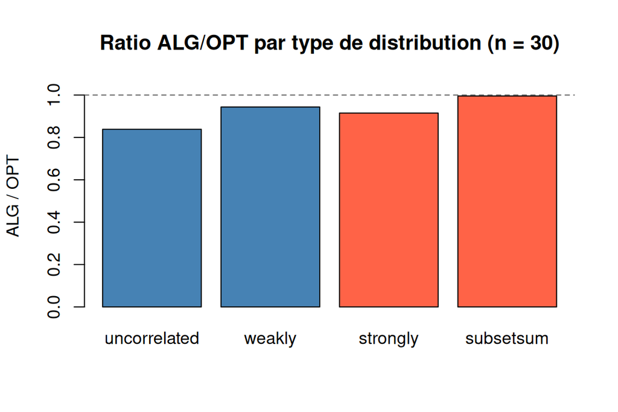

```r
set.seed(4)
types4 <- c("uncorrelated", "weakly", "strongly", "subsetsum")
ratios <- sapply(types4, function(t) {
  x   <- generate_knapsack(30, type = t)
  opt <- knapsack_dp(x$W, x$w, x$v)$value
  alg <- knapsack_adaptive(x$w, x$v, x$W)$value
  if (opt == 0) 1 else alg / opt
})
barplot(ratios, ylim = c(0, 1.05), ylab = "ALG / OPT",
        col = c("steelblue", "steelblue", "tomato", "tomato"),
        main = "Ratio ALG/OPT par type de distribution (n = 30)")
abline(h = 1, lty = 2, col = "grey40")
```

# 6 Q4 — Simulations

## 6.1 Accélération R vs C++

On mesure le temps moyen par appel sur une instance fixe, en moyennant sur plusieurs répétitions pour stabiliser la mesure.

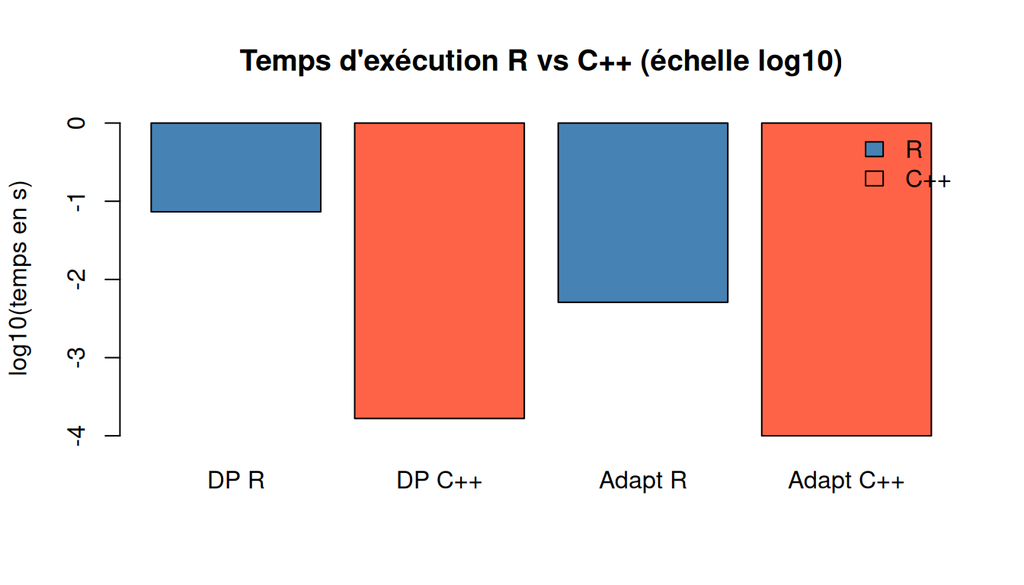

```r
set.seed(5)

# DP : n=50, W fixé à 5000
inst_b <- generate_knapsack(50, type = "uncorrelated")
inst_b$W <- 5000L
reps <- 30L

t_dp_r   <- system.time(for (i in seq_len(reps))
               knapsack_dp(inst_b$W, inst_b$w, inst_b$v))["elapsed"] / reps
t_dp_cpp <- system.time(for (i in seq_len(reps))
               knapsack_dp_Rcpp(inst_b$W, inst_b$w, inst_b$v))["elapsed"] / reps

# Heuristique adaptative : n=1000
inst_h <- generate_knapsack(1000, type = "uncorrelated")
t_ad_r   <- system.time(for (i in seq_len(reps))
               knapsack_adaptive(inst_h$w, inst_h$v, inst_h$W))["elapsed"] / reps
t_ad_cpp <- system.time(for (i in seq_len(reps))
               knapsack_adaptive_Rcpp(inst_h$w, inst_h$v, inst_h$W))["elapsed"] / reps

# Graphique : temps R vs C++ sur échelle log
times_all <- c(t_dp_r, t_dp_cpp, t_ad_r, t_ad_cpp)
labels_all <- c("DP R", "DP C++", "Adapt R", "Adapt C++")
cols_sp    <- c("steelblue", "tomato", "steelblue", "tomato")

bp <- barplot(log10(pmax(times_all, 1e-7)),
              names.arg = labels_all, col = cols_sp,
              ylab = "log10(temps en s)",
              main = "Temps d'exécution R vs C++ (échelle log10)")
speedup_dp <- t_dp_r / t_dp_cpp
speedup_ad <- t_ad_r / t_ad_cpp
text(bp[c(1,3)], log10(pmax(c(t_dp_r, t_ad_r), 1e-7)) - 0.4,
     sprintf("%.0f×", c(speedup_dp, speedup_ad)),
     col = "white", font = 2, cex = 1.1)
legend("topright", c("R", "C++"), fill = c("steelblue", "tomato"), bty = "n")
```

Le gain pour la PD dépasse largement l’objectif de 50–100× fixé dans les consignes. L’heuristique est plus modeste car elle ne fait qu’un seul passage en $O(n)$ — il y a moins de calcul à vectoriser.

## 6.2 Complexité empirique

### 6.2.1 Méthode naïve — $O(2^n)$

On fait varier $n$ de 5 à 22 et on mesure le temps d’exécution. La théorie prédit $T(n) = C \cdot 2^n$, soit $\log T(n) \approx \log C + n \log 2$. Si on trace $n$ en abscisse et $\log T$ en ordonnée, la pente doit être $\log 2 \approx 0{,}693$.

```r
set.seed(6)
ns_nv <- 5:22
times_nv <- sapply(ns_nv, function(n) {
  x    <- generate_knapsack(n, type = "uncorrelated")
  reps <- if (n <= 15) 100L else if (n <= 18) 10L else 1L
  as.numeric(system.time(
    for (i in seq_len(reps)) knapsack_naive(x$W, x$w, x$v)
  )["elapsed"]) / reps
})
times_nv <- pmax(times_nv, 1e-6)
```

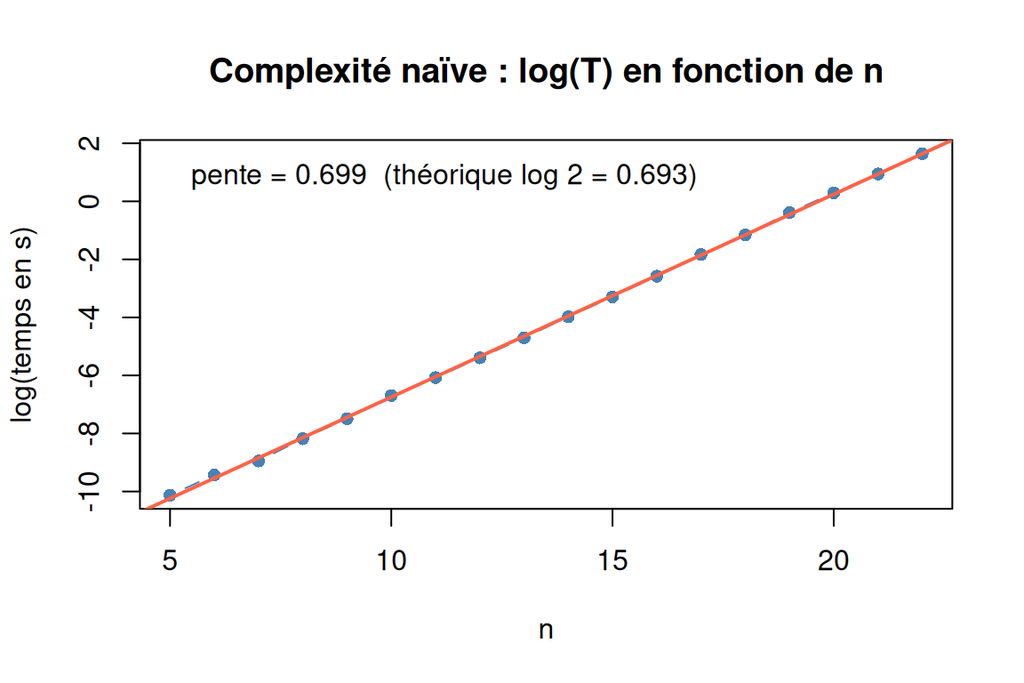

```r
plot(ns_nv, log(times_nv), type = "b", pch = 16, col = "steelblue",
     xlab = "n", ylab = "log(temps en s)",
     main = "Complexité naïve : log(T) en fonction de n")
fit_nv <- lm(log(times_nv) ~ ns_nv)
abline(fit_nv, col = "tomato", lwd = 2)
legend("topleft", bty = "n",
       legend = sprintf("pente = %.3f  (théorique log 2 = %.3f)",
                        coef(fit_nv)[2], log(2)))
```

### 6.2.2 Programmation dynamique — $O(n \cdot W)$

Avec les instances par défaut, $W \approx 0{,}5 \cdot n \cdot 500 = 250n$, donc $T(n) \approx C \cdot n \cdot 250n = C' n^2$. En log-log, la pente doit être $\approx 2$.

```r
set.seed(7)
ns_dp <- c(20, 40, 60, 80, 100, 150, 200)
times_dp <- sapply(ns_dp, function(n) {
  x    <- generate_knapsack(n, type = "uncorrelated")
  reps <- max(1L, 20L %/% (n %/% 20 + 1L))
  as.numeric(system.time(
    for (i in seq_len(reps)) knapsack_dp_Rcpp(x$W, x$w, x$v)
  )["elapsed"]) / reps
})
times_dp <- pmax(times_dp, 1e-6)
```

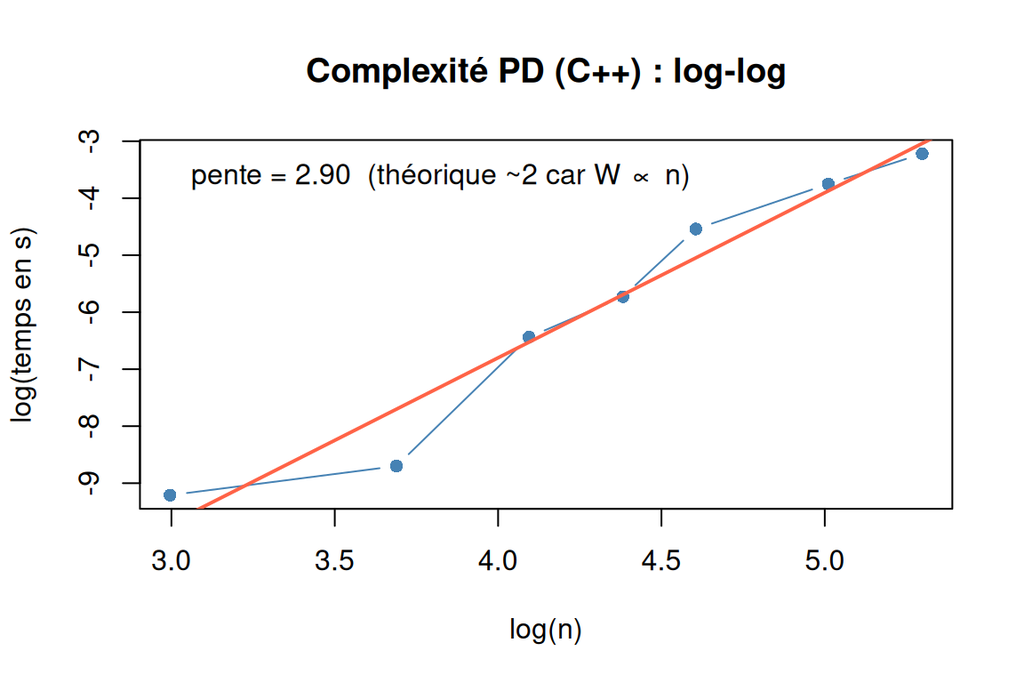

```r
plot(log(ns_dp), log(times_dp), type = "b", pch = 16, col = "steelblue",
     xlab = "log(n)", ylab = "log(temps en s)",
     main = "Complexité PD (C++) : log-log")
fit_dp <- lm(log(times_dp) ~ log(ns_dp))
abline(fit_dp, col = "tomato", lwd = 2)
legend("topleft", bty = "n",
       legend = sprintf("pente = %.2f  (théorique ~2 car W ∝ n)",
                        coef(fit_dp)[2]))
```

## 6.3 Ratio ALG/OPT selon le type et la taille

On fait varier $n$ et le type de distribution. Pour chaque combinaison, on calcule OPT par PD (C++) et on moyenne le ratio ALG/OPT sur 20 instances.

```r
set.seed(8)
ns_gap    <- c(20, 40, 60, 80, 100)
types_gap <- c("uncorrelated", "weakly", "strongly", "subsetsum")
nrep      <- 20L

gap_mat <- sapply(types_gap, function(t) {
  sapply(ns_gap, function(n) {
    mean(replicate(nrep, {
      x   <- generate_knapsack(n, type = t)
      opt <- knapsack_dp_Rcpp(x$W, x$w, x$v)$value
      alg <- knapsack_adaptive(x$w, x$v, x$W)$value
      if (opt == 0L) 1 else alg / opt
    }))
  })
})
```

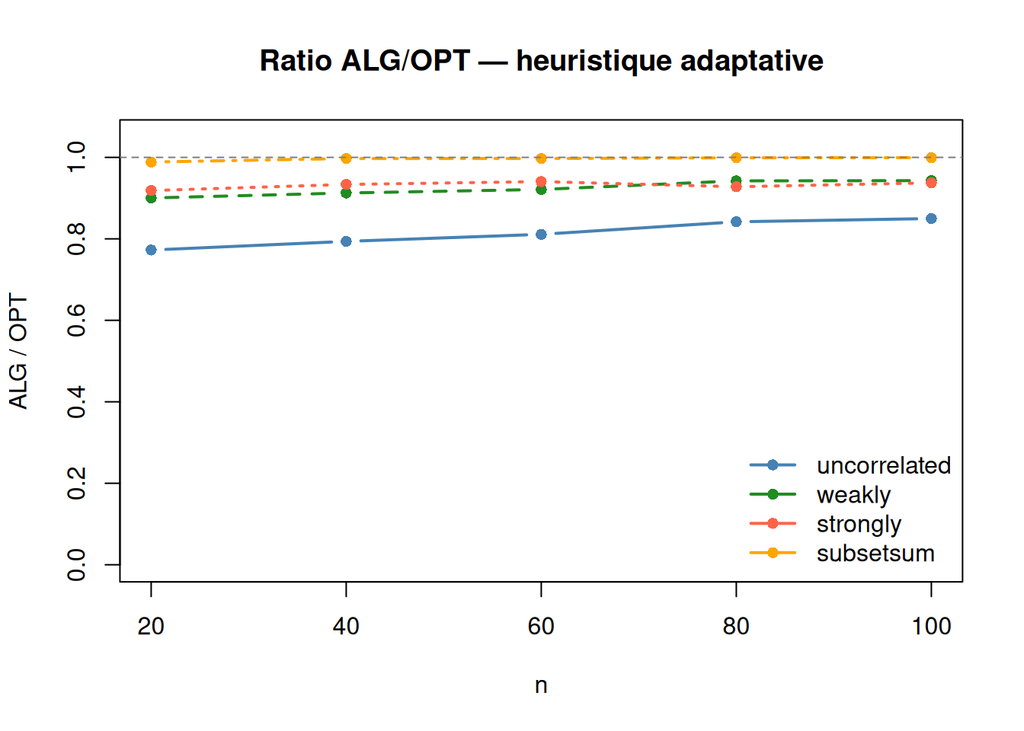

```r
cols <- c("steelblue", "forestgreen", "tomato", "orange")
matplot(ns_gap, gap_mat, type = "b", pch = 16, lwd = 2, col = cols,
        ylim = c(0, 1.05), xlab = "n", ylab = "ALG / OPT",
        main = "Ratio ALG/OPT — heuristique adaptative")
abline(h = 1, lty = 2, col = "grey50")
legend("bottomright", types_gap, col = cols, lwd = 2, pch = 16, bty = "n")
```

## 6.4 Comparaison des méthodes de seuil

On compare quatre approches sur $n = 50$, moyennées sur 30 instances par type. L’objectif est de montrer que notre $\Psi$ adaptative fait mieux que les formes fixes sur les distributions réalistes.

```r
set.seed(9)
nrep2 <- 30L

comp_mat <- sapply(types_gap, function(t) {
  colMeans(t(replicate(nrep2, {
    x   <- generate_knapsack(50, type = t)
    opt <- knapsack_dp_Rcpp(x$W, x$w, x$v)$value
    if (opt == 0L) return(c(greedy=1, lin=1, exp=1, adapt=1))
    L   <- min(x$v / x$w)
    U   <- max(x$v / x$w)
    c(
      greedy = knapsack_greedy(x$W, x$w, x$v)$value / opt,
      lin    = knapsack_online(x$W, x$w, x$v, psi_linear(L, U))$value / opt,
      exp    = knapsack_online(x$W, x$w, x$v, psi_exponential(L, U))$value / opt,
      adapt  = knapsack_adaptive(x$w, x$v, x$W)$value / opt
    )
  })))
})
```

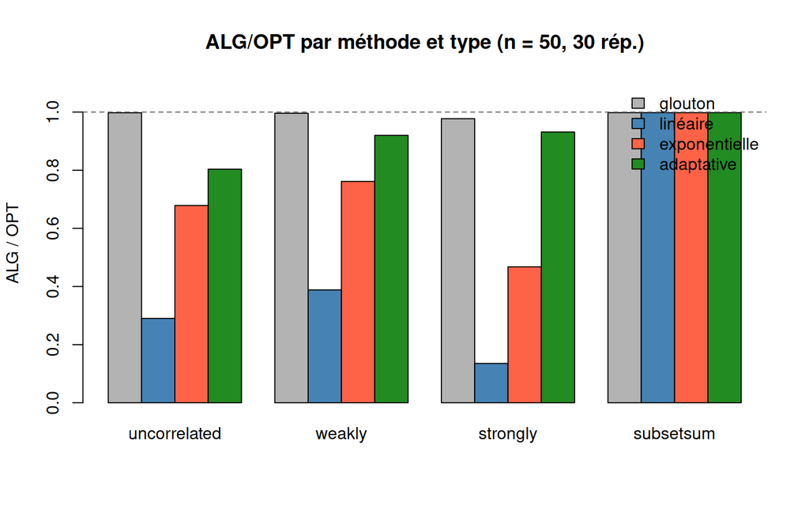

```r
barplot(comp_mat, beside = TRUE, ylim = c(0, 1.1),
        col = c("grey70", "steelblue", "tomato", "forestgreen"),
        ylab = "ALG / OPT", main = "ALG/OPT par méthode et type (n = 50, 30 rép.)",
        legend.text = c("glouton", "linéaire", "exponentielle", "adaptative"),
        args.legend = list(bty = "n", x = "topright"))
abline(h = 1, lty = 2, col = "grey40")
```

L’heuristique exponentielle est optimale au pire cas mais pas nécessairement la meilleure en moyenne. Notre $\Psi$ adaptative ajuste sa pente à la corrélation poids-valeur observée, ce qui lui permet de faire mieux sur les distributions réalistes tout en restant compétitive sur les cas difficiles.